# HW 2 - Airbnb

Annie Hou

02/07/2024

## Load packages and data

```r
library(tidyverse)
airbnb <- read_csv("data/airbnb.csv")
```

## Exercises

### Exercise 1

There are 13245 rows in the dataset.

### Exercise 2

Each row represents the information of an airbnb, including an id, price, neighborhood, accomodates, number of rooms and beds, ratings and score, and so on.

### Exercise 3

I chose two rows with x being the price because two rows allowing people to compare vertically between two neighborhoods or horizontally between several neighborhoods by price; also, one row would be too compact for the aesthetical measure.

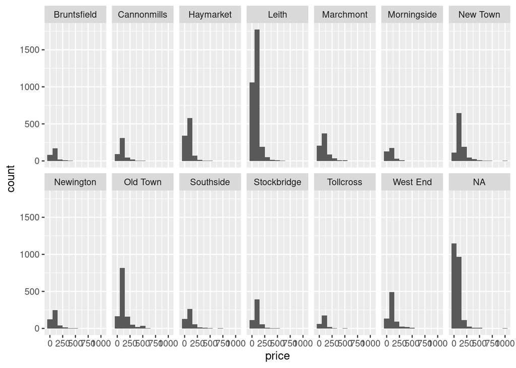

```r
ggplot(data = airbnb, mapping = aes(x = price)) +
  geom_histogram(binwidth = 100) +
  facet_wrap(~neighborhood, nrow=2)
```

### Exercise 4

We could see that neiborhoods such as Old Town and New Town tend to have higher prices with higher densities, which makes their median price also relatively higher. Also, their prices are more spreaded, which makes their standard deviation higher as well.

```r
top_neighborhoods <- airbnb %>%
  filter(!is.na(price)) %>%
  group_by(neighborhood) %>%
  summarize(median_price = median(price, na.rm = TRUE)) %>%
  arrange(desc(median_price)) %>%
  top_n(5, median_price)
```

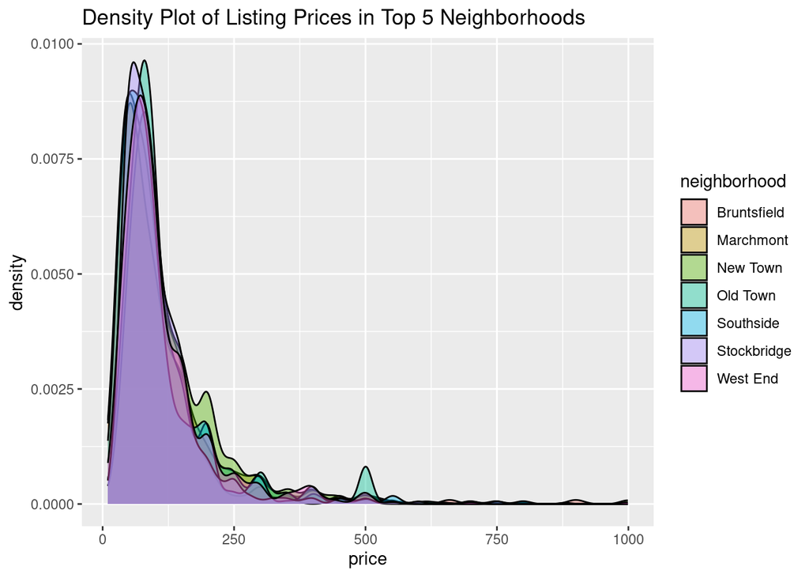

```r
filtered_data <- airbnb %>%
  filter(neighborhood %in% top_neighborhoods$neighborhood)

  ggplot(filtered_data, aes(x = price, fill = neighborhood)) +
  geom_density(alpha = 0.4) +
  labs(title = "Density Plot of Listing Prices in Top 5 Neighborhoods")
```

```r
summary_stats <- filtered_data %>%
  group_by(neighborhood) %>%
  summarize(
    minimum = min(price, na.rm = TRUE),
    mean = mean(price, na.rm = TRUE),
    median = median(price, na.rm = TRUE),
    std_deviation = sd(price, na.rm = TRUE),
    iqr = IQR(price, na.rm = TRUE),
    maximum = max(price, na.rm = TRUE)
  )
print(summary_stats)
```

```
## # A tibble: 7 × 7
##   neighborhood minimum  mean median std_deviation   iqr maximum
##   <chr>          <dbl> <dbl>  <dbl>         <dbl> <dbl>   <dbl>
## 1 Bruntsfield       10  99.4     80          90.2  72.5     900
## 2 Marchmont         10 111.      80          90.7  90       570
## 3 New Town          12 136.     100         109.   86.5     999
## 4 Old Town          15 128.      90         110.   76       999
## 5 Southside         10 107.      80          99.3  70       800
## 6 Stockbridge       21 104.      85          77.6  66       750
## 7 West End          19 116.      90          93.3  80       999
```

### Exercise 5

I chose the box plot because it could provide insights into the median, quartiles, and potential outliers in the data. For example, some neighborhoods like Old Town and Leith have more spreaded dat points, meaning that their reviews rating tend to fluctuate and vary a lot. Some neighborhoods like New Town has a relatively smaller range of interquartile data, which means that the ratings tend to be close together around the same level.

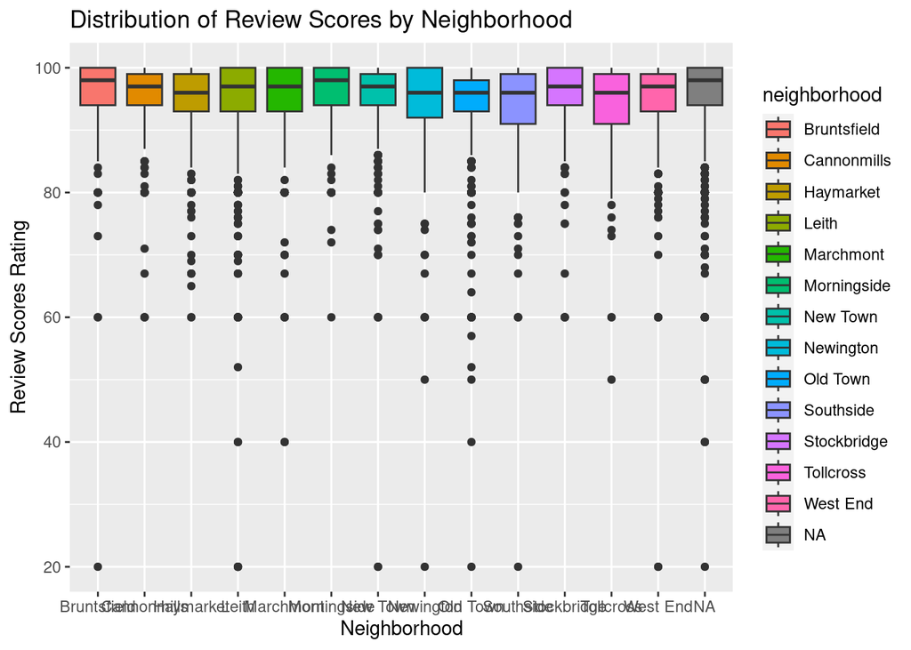

```r
ggplot(data = airbnb, aes(x = neighborhood, y = review_scores_rating, fill = neighborhood)) +
  geom_boxplot() +
  labs(
    title = "Distribution of Review Scores by Neighborhood",
    y = "Review Scores Rating",
    x = "Neighborhood"
  )
```